# Quantitative Genetics – PCB6555

Genomic Selection – GBLUP

Felipe Ferrão and Marcio Resende Jr

University of Florida – November, 2020

**Recapping:**

- We, initially expressed genotypic means, breeding value and genotypic variance as a function of allele frequencies and genotypic values and showed that we are able to distangle the causal variance components, using information from resemblance between relaties
- The use o multivariate mixed model, combining to pedigree information, allows us to rank genotypes and understand the correlation between traits and environments

**Plan for today:**

- Build a Genomic Relationship Matrices using outcrossing species and inbreeding
- Expand the mixed model analysis for fitting a GBLUP model
- Genomic Selection using cross-validation

# 1 Theory

## 1.1 Introduction

Along the curse, we demonstrated that the traditional BLUP approach relies on pedigree information to define the covariance between relatives. Formally, the vector of random effects (e.g., breeding values) is assumed to be multivariate normal, where the variance parameter is indexed by the numerator relationship matrix (called **A** matrix). The connection between traditional BLUP and genomic selection (GS) studies is the computation of this covariance using DNA information: genomic relationship matrix (called **G** matrix). The replacement of the **A** matrix by the **G** matrix constitutes the theoretical basis of the GBLUP approach.

In this section we will discuss important aspects for GBLUP implementation, including:

- Properties of the realized genomic relationship (**G** matrix);
- How to implement the GBLUP in `asreml R`;
- How to acess the predictive ability via cross-validation;

## 1.2 Realized Genomic Relationships

### 1.2.1 VanRaden’s first genomic relationship matrix

Classical paper published by [Van Raden 2008](https://www.sciencedirect.com/science/article/pii/S0022030208709901), where **G** matrix can be obtained by at least 3 methods. Below the first and most popular:

$$G= \dfrac{ZZ'}{2 \sum p_i (1-p_i)} = \dfrac{(M-P)(M-P)'}{2 \sum^m_{j=1} p_j (1-p_j)}$$

- **M** = original molecular marker matrix, but centered. It is a table allele-sharing matrix with columns *m* (total number of markers) and *n* rows (total number of genotyped individuals).
- **MM’** = when performed **MM’**, in the diagnoal elements we have the number of homozygous loci for each individual and off-diagnoal measure the number of alleles shared by individuals. In another others, we have a first metric of relationship between individuals using molecular markers
- **P** = a matrix of the base population adjusted for the minor allele frequency of loci. The ith column of **P** is obtained as $2(p_i-0.5)$ where $p_i$ is the allele frequency for the minor allele. This kind of correction is important to weights the genotype matches in a way that give more weight to matches that are less likely to occur by chance without shared ancestry.
- **ZZ’** = subtraction of **P** gives more credit to rare alleles than to common alleles . Genomic inbreeding coefficient is greater if the individual is homozygous for rare alleles than if homozygous for common alleles. Howvever, **ZZ’** is not relationships. Relationships are standardized covariances. The variance we need to divide by is the genetic variance or, in other words, the variance of the breeding values of a set of animals.
- $2\sum^m_{j=1} p_j (1-p_j)$ = scales **G** to be analogous to the numerator relationship matrix **A** . Since **ZZ’** is a covariance matrix and its elements get larger as we include more markers, we can remove the influence of marker number by using this scale factor. Thus, the expected off-diagonal value for half-sibs should be 0.25, for example

### 1.2.2 Examples

#### 1.2.2.1 Coffee

- [Ferrão et al. (2018)](https://link.springer.com/article/10.1007/s11295-017-1171-7).
- Coffee example.
- Difference between **A** computed via pedigree collected on the family level (half-sib individuals) and the same pedigree computed at the genomic level.

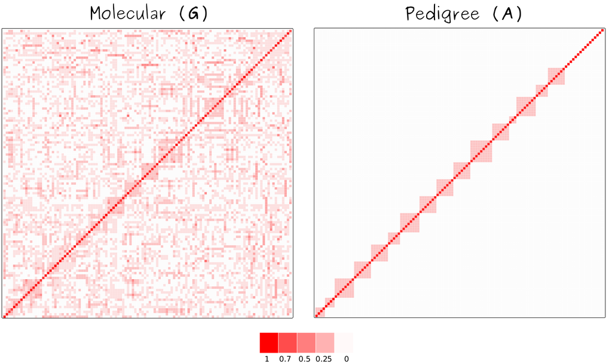

Coffee data set, difference between A and G matrices

#### 1.2.2.2 Potato

- [Endelman, et al (2018)](https://www.genetics.org/content/209/1/77)
- Deeper pedigree for potato
- Comparison of off-diagonal elements for the additive covariance matrices estimated from markers (G) vs. pedigree (A) for the population of 571 clones.

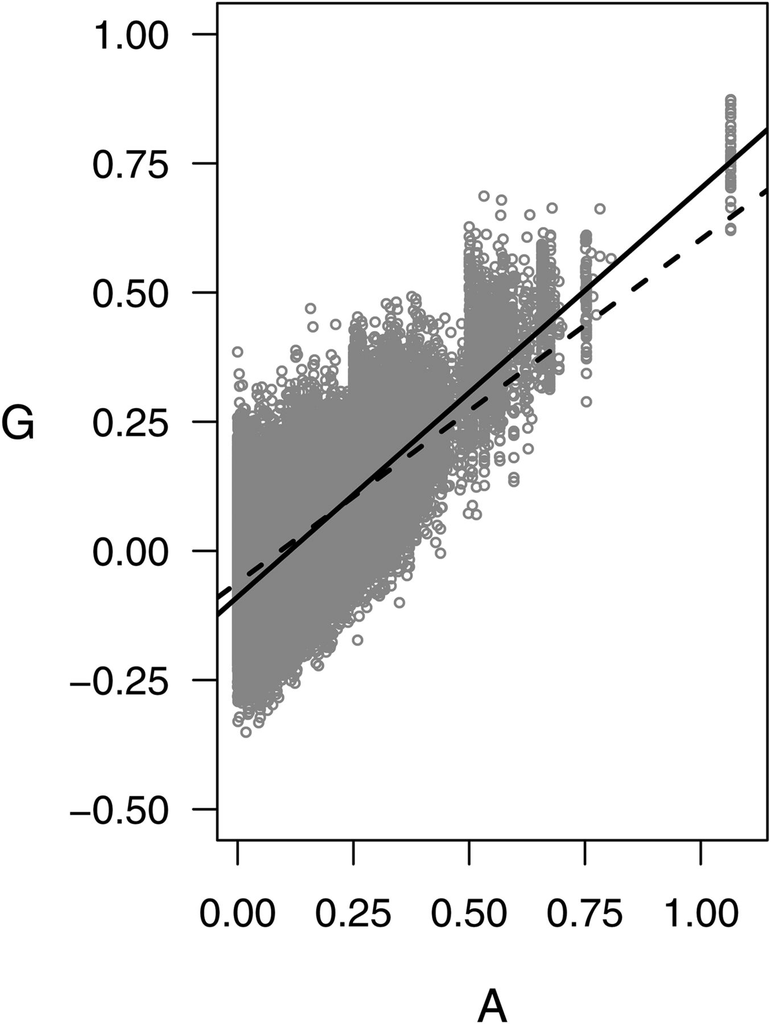

Off-diagonal from G and A matrices for potato

## 1.3 Theory on GBLUP

In a matrix format, we have the same mixed model framework used in the pedigree analysis, when the animal models were presented:

$$y = Xb + Zu + e$$

where **y** represents a vector of observed (measured) phenotype values, **b** and **u** are vectors of unknown parameters for “fixed” and “random” effects, while **X** and **Z** are corresponding design matrices and finally **e** is a vector of residuals. The covariance matrix of additive effect can be written as $G_0=G\sigma^2_u$, where **G** is the genomic (realized)relationship matrix and $\sigma^2_u$ is additive genetic variance.

$$\begin{bmatrix} {X'R^{-1}X} & {X'R^{-1}Z} \\ {Z'R^{-1}X} & {Z'R^{-1}Z} + {G^{-1}\lambda} \end{bmatrix}
\begin{bmatrix} {\hat{b}}\\ {\hat{u}} \end{bmatrix}
=
\begin{bmatrix} {X'R^{-1}y} \\ {Z'R^{-1}y} \end{bmatrix}$$

$$\hat{b} = (X'V^{-1}X)^{-1}XV^{-1}y$$

$$\hat{u} = GZ'V^{-1}(y-X\hat{b})$$

**Notes**

- With the GBLUP we can obtain predictions of **u**, which represents the BLUPs or **genomic estimated breeding values (GEBVs)** for all individuals included in the **G** matrix
- Any model that has been developed in BLUP can be immediately translated into GBLUP. This includes GxE and multi trait models.
- All genotyped individuals can be included, either with phenotype or not.

## 1.4 Cross-validations

- How good is my model to perform predictions based on genomic data?
- In other words, using only genomic data, can I predict the phenotypic performance of a given individual?

To solve this practical question we need to use **cross-validation.** In the cross-validation, we sampling phenotypic values from only one part of the data set (called the **training set**), fitting a prediction model and predicting for the rest of the data set (called **test data set**). In short:

- TRN data set: genomic + phenotypic = predictive model
- TST data set: predictive model + genomic = predictions

By breaking the data in traning and test data sets, we can have an unbiased estimate of model’s prediction accuracy. The most common metric to evaluate the predictive performance is the Person’s **correlation** between phenotype and genomic estimated breeding value.

There are different flavors for cross-validation. k-fold cross-validation means is one of the most popular in the GS literature. Below, we have an example of 10-fold cross-validation. For that, the data are split in 10 folds of approximately equal population size, and information from each fold is used once for test while the others are used as training. In this format, a total of 10 GS models are fitted.

[figure not shown]

k-fold cross-validation. [Reference](https://imada.sdu.dk/~marco/Teaching/AY2010-2011/DM825/)

# 2 Practice

- Building Genomic Relationship Matrices using outcrossing species and inbreeding
- Fitting GBLUP model
- Genomic Selection using cross-validation

## 2.1 Building Genomic Relationship Matrices

- There are different R packages that can also be used to compute to compute **A** and **G** matrices in different formats.
- Examples to compute the **A** matrix:
  - AGHmatrix (`Amatrix`) – [link](https://github.com/prmunoz/AGHmatrix)
  - Pedigree (`makeA`) – [link](https://www.rdocumentation.org/packages/pedigree/versions/1.4)
  - Pedigreem (`getA`) – [link](https://cran.r-project.org/web/packages/pedigreemm/index.html)
  - synbreed (`kin`) – [link](https://www.rdocumentation.org/packages/synbreed/versions/0.12-9)

### 2.1.1 Data set

- Download the pine data (`maritimepinegpData.rda`). An example from [Isik et al., 2017](https://www.springer.com/gp/book/9783319551753).
  - [Link for the example](https://drive.google.com/drive/folders/0B9JWAJgh6v3Cflppc09XUXU3WHRvX29qY1IxNDVFaEdpblA4SFNXOThQV2ZDRVkxWlZWSEk).
  - Original Description: 654 individual trees at 2600 SNPs. Markers with high rates of missing data or very low minor allele frequencies were removed. SNP markers were converted to numeric values (012 format).
- Wheat data set from the `BGLR` package:
  - Download using the `data(wheat)`
  - Original description: collection of 599 historical CIMMYT wheat lines. The wheat data set is from CIMMYT’s Global Wheat Program. The phenotypic trait considered here was the average grain yield (GY) of the 599 wheat lines evaluated in each of these four mega-environments. SNP markers were converted to numeric values (01 format for homozygous lines).
- We will use the `AGHmatrix` to compute both **G** matrices.

**`AGHmatrix` Codes**

```r
###############################
## Pinus data set
###############################
load("/home/lferrao/Dropbox/classes/2020/QuantitativeGenetics/week 12_GBLUP1/maritime pine gpData.rda")
gp.num$geno[1:5,1:5]

# G matrix
library(AGHmatrix)
Gpinus = Gmatrix(gp.num$geno)
range(diag(Gpinus))
range(Gpinus[lower.tri(Gpinus)])
mean(Gpinus[lower.tri(Gpinus)])

# Simulation 1
# i) What happens to the diag and off-diag of the G matrix if there is a clone?
X = gp.num$geno
dim(X)
Xclone = rbind(X,X[654,])
dim(Xclone)

Gpinus_clone = Gmatrix(Xclone)
range(diag(Gpinus_clone))
range(Gpinus_clone[lower.tri(Gpinus_clone)])
hist(Gpinus_clone[lower.tri(Gpinus_clone)])
mean(Gpinus_clone[lower.tri(Gpinus_clone)])
table(duplicated(diag(Gpinus_clone)))
Gpinus_clone[650:655,650:655]

# Simulation 2
#ii) What happens to the diag if there is a totally homozygous individuals?
Xhomo = rbind(X,rbinom(ncol(X), 1,0.5)*2)
dim(Xhomo)
Gpinus_homo = Gmatrix(Xhomo)
range(diag(Gpinus_homo))

###############################
## Wheat data set
###############################
library(BGLR)
data(wheat)
Gwheat = Gmatrix(wheat.X*2) # important, check how the data was codified
range(Gwheat[lower.tri(Gwheat)])

# Subset of the matrix
plot(as.vector(Gwheat[1:100,1:100])~ as.vector(wheat.A[1:100,1:100]))
range(diag(Gwheat))
```

### 2.1.2 Results

**Summary**

|  | G matrix pine | A matrix wheat | G matrix wheat |
| --- | --- | --- | --- |
| dimension | 654x654 | 599x599 | 599x599 |
| range off-diagonal | [-0.14 - 0.63] | [0 -1.99] | [-0.80 - 2.77] |
| mean off-diag | -0.0015 | 0.37 | -0.003 |
| range of diagonal | [0.86 - 1.16] | [1.55-2] | [1.32 - 2.97] |
| mean diagonal | 0.99 | 1.98 | 2 |

**Main considerations**

1. Difference between pine and wheat **G** matrices are mostly driven by the reproductive system of each species (outcrossing vs. inbred).
2. Negative values for the **G** matrix can be observed and indicate that some pairs of individuals are less related than expected. For individuals that are suspected to have no relationships, the realized relationship can oscillate between positive and negative values.
3. The average value of the diagonal of **G** is 1 if there is no inbreeding. Variations around this value are possible, in particular, because some regions in the genome are more homozygous than expected based on HW expectations.
4. **G** matrix can be viewed as an estimator of twice the correlation matrix of alleles among individuals in a population and hence we expect a maximum diagonal value of 2. Coefficients larger than 2 are possible in hyhly inbred lines. It occurs because of the weight of rare alleles. Eventual homozygosity individuals for rare alleles has more weight when computing the **G** matrix.
5. Warning: matrix **G** might (and usually is) singular. Rank deficience matrix can be observed in some cases and therefore the matrix is not ivertible.

## 2.2 Genomic selection

### 2.2.1 Coffee data set

| Effect | Observation | Levels |
| --- | --- | --- |
| year | year in which the plants were evaluated | 4 |
| block | replication number | 3 |
| trat | coffee genotype | 119 |
| yield | total yield (kg) per plot | numeric |
| Numb.Plants | number of plants evaluated per plot | numeric |

### 2.2.2 Defining the model

**Implicit GxE model**

$$y_{ijk} = \mu + L_i + B(L)_{ij} + \underline{G(L)_{ik}} + \underline{e_{ijk}}$$

- $\mu$ is the overall mean;
- $L_i$ = effect of year i
- $B(L)_{ij}$ = effect of block j nested within year i
- $G(L)_{ik}$ = random effect of genotype nested within year, where $G_{k} \sim N(0, \Sigma_g \otimes G\sigma^2_g)$
- $e_{ijk}$ = random residual effect, where where $e_{ijk} \sim N(0, I\sigma^2_e \otimes \Sigma_r )$

**Comments**

- The relationship matrix (**G**), or its inverse, that is previously computed based on molecular markers, both can be used in ASReml-R.
- Use of the G inverse can result in some computational gain in terms of runtime. However, you must specify it as `attr(Ginv,"INVERSE")<-TRUE`.
- The number and order of levels have to match perfectly the ones used for the associated genetic factor (eg, `animalID` or `treeID`).

**Codes**

```r
library(asreml)
library(openxlsx)
library(dplyr)
library(AGHmatrix)
library(asremlPlus)

load("/home/lferrao/Dropbox/classes/2020/QuantitativeGenetics/week 12_GBLUP1/coffee_A_G_y.Rdata")
A=as.matrix(A)          #make sure that pedigree matrix is a matrix class

boxplot(y$Yield~y$year) # Any insight on the GxE interaction?
mean(diag(G_VanRaden1)) # Any insight on inbreeding?

# Model1 (no GxE)
mm1 = asreml(fixed = Yield ~block%in%year + year ,
             random = ~ trat,
            data = y)
infoCriteria(mm1)

# Model 2 (GxE; id genotypes; id residuals)
mm2 = asreml(fixed = Yield ~block%in%year + year ,
             random = ~ year:trat,
            data = y)
infoCriteria(mm2)

# Model 3 (GxE; id genotypes; diag residuals)
mm3 = asreml(fixed = Yield ~block%in%year + year ,
             random = ~ year:trat,
            residual=~dsum(~id(units)|year),
            data = y)
infoCriteria(mm3)

# Model 4 (GxE; A pedigree; diag residuals)
mm4 = asreml(fixed = Yield ~block%in%year + year ,
             random = ~ corv(year):vm(trat,A),
             residual=~dsum(~id(units)|year),
             data = y)
infoCriteria(mm4)

# Model 5 (GxE; GBLUP; diag residuals)
mm5 = asreml(fixed = Yield ~block%in%year + year ,
             random = ~ corv(year):vm(trat,G_VanRaden1),
             residual=~dsum(~id(units)|year),
             data = y)
infoCriteria(mm5)

# Model 6 (corh GxE; GBLUP; diag residuals)
mm6 = asreml(fixed = Yield ~block%in%year + year ,
             random = ~ corh(year): vm(trat,G_VanRaden1),
             residual=~dsum(~id(units)|year),
             data = y)
infoCriteria(mm6)
plot(mm6)

# Alternative way
Ginv = solve(G_VanRaden1)
attr(Ginv,"INVERSE")<-TRUE
mm7 = asreml(fixed = Yield ~block%in%year + year ,
             random = ~ corh(year): vm(trat,Ginv),
             residual=~dsum(~id(units)|year),
             data = y)
infoCriteria(mm7)

# If you forget to specif that Ginv is an inverse
Ginv1 = solve(G_VanRaden1)
mm7 = asreml(fixed = Yield ~block%in%year + year ,
             random = ~ corh(year): vm(trat,Ginv1),
             residual=~dsum(~id(units)|year),
             data = y)
infoCriteria(mm7)
```

### 2.2.3 Results

**Godness of fit**

- Improvements when GxE is modelled.
- Large improvement when we include pedigree and genomic information

|  | trat | GxE | residual | AIC |
| --- | --- | --- | --- | --- |
| m1 | id | no | id | 7654.86 |
| m2 | id | corv | id | 7645.967 |
| m3 | id | corv | diag | 7630.934 |
| m4 | A | corv | diag | 7567.757 |
| m5 | G | corv | diag | 7539.43 |
| m6 | G | corh | diag | **7512.836** |

**Genotype Ranking**

- Cross-over ranking across the years when EBV (`m4`) vs. GEBV (`m5`) are compared.
- In theory, GEBV should be considered to guide breeding decisions. Some reasons:
  - Statistically, better goodness of fit.
  - Pedigree, in many cases, has recording errors.
  - Realized pedigree can capture Mendelian segregation.
  - Genomic data, in general, results in better predictive accuracy

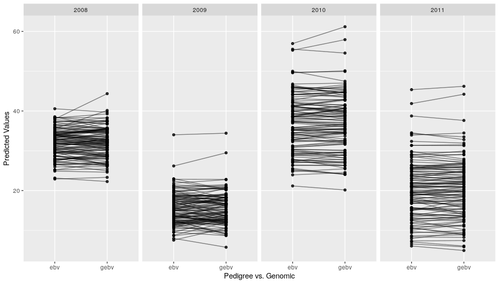

EBV vs. GEBV for ranking

## 2.3 GBLUP and cross-validation

We can define different types of cross-validation. It depends on what is the main question addressed in the breeding program. Below an example in maize, where cross-validation was performed within and across years, with the main goal to test the importance to incorporate dominance effects for hybrid predictions [(Ferrão et al., 2020)](https://acsess.onlinelibrary.wiley.com/doi/full/10.1002/csc2.20096).

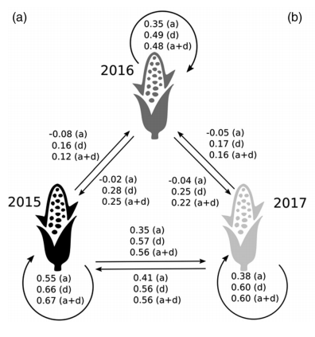

Cross-validation depending of the final objective

**Step-by-step**

1. Create the 10 folds (`sample` function)
2. For each fold, split the data set into training and test
3. In the training, replace the phenotypic values associated to the individuals for the test as `NA`
4. Fit the model using the training data set
5. Compare the predicted values of the individuals in the test data set with the real phenotypic value.

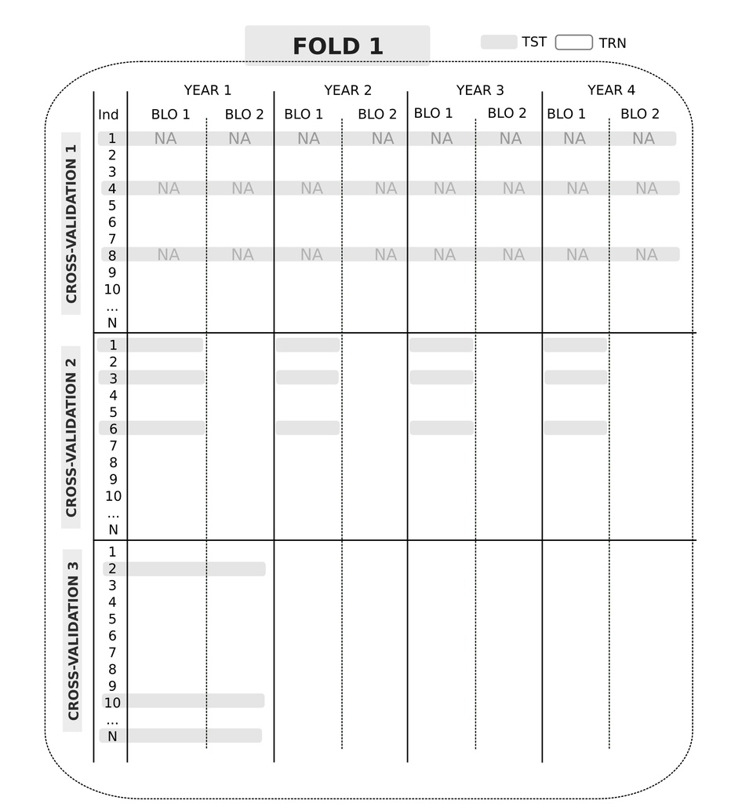

In the example we are running the cross-validation 1

**Codes**

```r
# Download the data
load("/home/lferrao/Dropbox/classes/2020/QuantitativeGenetics/week 12_GBLUP1/coffee_A_G_y.Rdata")

# Organize the phenotypic data
# --- The uniqueID will be important to track genotypes in the TST and TRN data sets
df=y %>%
  mutate(uniqueID = paste(trat, block, year, sep="_"))
head(df)

# i) Creating the fold
n=119                               # original number of individuals
k=10                                # how many folds/partitions
set.seed(123)                       # same fold/partitions division every time
folds=sample(1:k,size=n,replace=T)  # creating random partitions
folds                               # ind assigned to diff folds
table(folds)                        # number of ind per fold

# Genomic selection using 10-fold CV scheme
r2 = vector()                        # empty vector to save the accuracy values
for(i in 1:max(folds)){              # loop across the folds
  # i=1

  # ii. Creating the test data set (individuals that we will predict)
  tst=which(folds==i)               # individuals in the test data set
  y.tst = df %>%
    filter(trat %in% tst) %>%
    droplevels()                    # phenotypic value for the test data set

  # iii. Training data set
  y.trn = df %>%                    # replace phenotypic value for test to NA
    mutate(yNA = replace(Yield, trat %in% tst,NA))

  # iv. GBLUP model
  # Important:i) Response variable (yNA) and ii) Data set (y.trn)
  mm = asreml(fixed = yNA ~block%in%year + year,
             random = ~ corh(year): vm(trat,G_VanRaden1),
             residual=~dsum(~id(units)|year),
             na.action=na.method(y="include"),
             data = y.trn)

  # v. Predictions for all individuals (including the tst data set)
  yHat =predict(mm,classify="trat:block:year",sed=T)$pvals

  # Creating an unique id to extract ind from the tst data set
  yHat.tst = yHat %>%
       mutate(uniqueID = paste(trat,block,year,sep="_")) %>%
       droplevels()

  # Mergin predicted value and original value for the tst data set
  merged = merge(yHat.tst, y.tst, by="uniqueID")

  # Pearson's correlaction
  r2[i] = cor(merged$predicted.value,merged$Yield,use="complete")
}

mean(r2)

# Questions:
# i. Is this cross-validation scheme valid for a breeding program?
# ii. Can we measure predictive accuracy using other metrics?
```

# 3 Final Considerations

- There are four main mechanisms responsible for the divergence between the use of realized relationships in a GBLUP context from their expectations (in a pedigree BLUP scenario): random Mendelian segregation, segregation distortion, selection, and pedigree recording errors.
- The expected genetic gain is an important metric to quantify the progress of a breeding program and can be represented as: $GP = \dfrac{ir_a\sigma_a}{L}$, where *i* is the selection intensity, *r* a is the selection accuracy, $\sigma_a$ is the square root of additive genetic variance, and *L* is the cycle length. Using this equation, GS has potential to capitalize on all four of the components.
  - Selective accuracy: conclusion based on molecular information tends to be more reliable and can compute the realized relationship among individuals, instead of an expected value supported by pedigree records.
  - Cycle length: In order to advance generations and accelerate the gain per unit of time, genomic predictions can be performed during seedling phase.
  - The use of many cycles per year directly affects the selection intensity and genetic variance, the two remaining components in the equation. In general, the selection intensity is raised by the ability to evaluate a large breeding population and consider large screening nursery. Consequently, new genes and combination of them, not present in the breeding program, may be incorporated in the evaluation process

# 4 References

- Isik et al., 2017. Genetic Data Analysis for Plant and Animal Breeding. [Book link](https://www.springer.com/gp/book/9783319551753)
- Ferrão, LFV.; Garcia, AAF.; Ortiz, R.Genomic Selection - State of Art. Book: Genetic Improvement of Tropical Species. In: Hugo Campos and Peter D. S Caligari (Ed.). Springer, 2017. [Book link](https://www.springer.com/gp/book/9783319598178)
- Meuwissen et al., 2001. Prediction of total genetic value using genome-wide dense marker maps. [Link for the original paper](https://www.genetics.org/content/157/4/1819)
- Mrode, 2014. Linear Models for the Prediction of Animal Breeding Values. [Book link](https://www.amazon.com/Linear-Models-Prediction-Animal-Breeding/dp/1845939816)
- Pérez, P., & de los Campos, G. (2014). BGLR: a statistical package for whole genome regression and prediction. Genetics, 198(2), 483-495. [Link paper](http://genomics.cimmyt.org/BGLR-extdoc.pdf)
- Van Raden, 2008. Efficient Methods to Compute Genomic Predictions [Link for the paper](https://www.sciencedirect.com/science/article/pii/S0022030208709901)